# Data Challenge 14

2026-10-24

```r
library(tidyverse)
```

# Analisi dati sui risultati di partite di scacchi

```r
df <- read.csv("data.csv")
```

## C’è un vantaggio a giocare per primi?

Contiamo in quante partite ha vinto il bianco, in quante il nero e in quante si è pareggiato.

```r
df2 <- df |>
  group_by(Score) |>
  summarize(count = n())
df2
```

```
## # A tibble: 3 × 2
##   Score count
##   <dbl> <int>
## 1   0   15224
## 2   0.5 28666
## 3   1   21163
```

Escludendo le patte, restano 36387 partite, di cui 21163 vinte dal bianco e 15224 dal nero. Semplificando, supponiamo che le variabili casuali che descrivono la vittoria del bianco siano indipendenti e identicamente distribuite. Testiamo l’ipotesi nulla: la probabilità di vittoria del bianco è 50%.

```r
prop.test(21163, 36387, p = 0.5, correct = FALSE)
```

```
##
##  1-sample proportions test without continuity correction
##
## data:  21163 out of 36387, null probability 0.5
## X-squared = 969.35, df = 1, p-value < 2.2e-16
## alternative hypothesis: true p is not equal to 0.5
## 95 percent confidence interval:
##  0.5765319 0.5866685
## sample estimates:
##         p
## 0.5816088
```

Un p-value così basso porta a rifiutare l’ipotesi nulla, dunque sembra esistere un vantaggio a giocare per primi, essendo il numero delle vittorie del bianco maggiore di quello relativo alle vittorie del nero.

## Distribuzione dei punteggi

Assegnamo ai giocatori un punto per le vittorie, mezzo per le patte e zero per le sconfitte.

```r
df3 <- df |>
  group_by(White) |>
  summarise(punti = sum(Score))
df3
```

```
## # A tibble: 6,606 × 2
##    White punti
##    <int> <dbl>
##  1     1  20.5
##  2     3   1
##  3     4  11.5
##  4     5   1.5
##  5     6   2.5
##  6     7   9
##  7     9   0
##  8    10   2.5
##  9    11   6
## 10    12   3.5
## # ℹ 6,596 more rows
```

```r
df4 <- df |>
  mutate(InvScore = 1 - Score) |>
  group_by(Black) |>
  summarise(punti = sum(InvScore))
df4
```

```
## # A tibble: 6,582 × 2
##    Black punti
##    <int> <dbl>
##  1     1  10.5
##  2     2   0.5
##  3     3   2
##  4     4  12
##  5     5   2.5
##  6     6   4.5
##  7     7   5
##  8     8   0
##  9     9   0.5
## 10    10   0.5
## # ℹ 6,572 more rows
```

```r
# a questo dataset mancano i giocatori che hanno giocato solo col bianco o solo col nero
df5 <- full_join(df3, df4, join_by(White == Black)) |>
  mutate(punti = punti.x + punti.y) |>
  select(White, punti) |>
  rename(giocatore = White)
df5
```

```
## # A tibble: 7,301 × 2
##    giocatore punti
##        <int> <dbl>
##  1         1  31
##  2         3   3
##  3         4  23.5
##  4         5   4
##  5         6   7
##  6         7  14
##  7         9   0.5
##  8        10   3
##  9        11   9
## 10        12   7
## # ℹ 7,291 more rows
```

```r
df6 <- anti_join(df3, df4, join_by(White == Black)) |>
  select(White, punti) |>
  rename(giocatore = White)
df7 <- anti_join(df4, df3, join_by(Black == White)) |>
  select(Black, punti) |>
  rename(giocatore = Black)

# questo invece contiene tutti i giocatori
df8 <- df5 |>
  union(df6) |>
  union(df7) |>
  mutate(punti = replace_na(punti, 0)) |>
  group_by(giocatore) |>
  summarise(somma = sum(punti)) |>
  arrange(giocatore) |>
  rename(punti = somma)
df8
```

```
## # A tibble: 7,301 × 2
##    giocatore punti
##        <int> <dbl>
##  1         1  31
##  2         2   0.5
##  3         3   3
##  4         4  23.5
##  5         5   4
##  6         6   7
##  7         7  14
##  8         8   0
##  9         9   0.5
## 10        10   3
## # ℹ 7,291 more rows
```

Possiamo ora guardare l’istogramma delle frequenze:

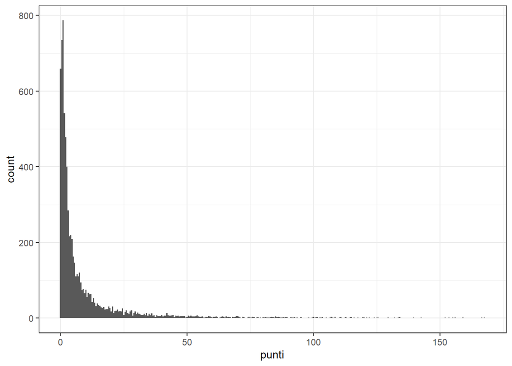

```r
ggplot(data = df8) +
  geom_histogram(mapping = aes(x = punti), binwidth = 0.5) +
  theme_bw()
```

La distribuzione è asimmetrica, probabilmente perché molti giocatori hanno giocato solo pochissime partite o ne hanno comunque vinte poche rispetto a quei pochi giocatori che vincono spesso.

## La somma dei punti ELO è sempre zero

Dimostrazione. Procediamo per induzione sul numero n di partite giocate: - Caso base: $n = 0$, visto che nessuna partita è ancora stata giocata e i giocatori partono tutti con ELO zero, allora la somma degli ELO dei giocatori è zero.

- Passo induttivo: Supponiamo per ipotesi induttiva che per $n = \lambda$ la somma degli ELO di tutti i giocatori sia zero; dimostriamo che essa è pari a 0 anche per $n = \lambda + 1$. Sia la $(\lambda + 1)$-esima partita giocata tra il giocatore $i$ e il giocatore $j$, siano inoltre $r_i$ e $r_j$ i loro ELO prima dello scontro, consideriamo la somma dei loro ELO dopo lo scontro. Essa vale:
  $$r_i + \kappa (s_{i,j} - \mu_{i,j}) + r_j + \kappa
  (s_{j,i} - \mu_{j,i}) = r_i + r_j + \kappa ((s_{i,j} + s_{j,i}) -
  (\mu_{i,j} + \mu_{j,i})) = r_i + r_j + \kappa (1 - 1) = r_i +
  r_j$$
  e dunque la somma degli ELO resta invariata tra prima e dopo lo scontro. La somma degli ELO di tutti i giocatori resta dunque zero.

## Calcolo dei punteggi ELO dei giocatori

```r
# Inizialmente hanno tutti 0 punti
df9 <- df8 |>
  mutate(punti = 0) |>
  rename(elo = punti);

# Poi vedo tutte le partite e aggiorno i punteggi elo
for (i in seq_len(nrow(df))) {

  bianco <- df$White[i]
  nero   <- df$Black[i]
  score  <- df$Score[i]

  # Trova le righe dei due giocatori
  index_bianco <- match(bianco, df9$giocatore)
  index_nero <- match(nero, df9$giocatore)

  # Elo prima dello scontro
  R_bianco <- df9$elo[index_bianco]
  R_nero <- df9$elo[index_nero]

  # Punteggio atteso del bianco
  E_bianco <- 1 / (1 + 10^((R_nero - R_bianco) / 400))

  # Aggiorna entrambi gli Elo
  variazione <- 25 * (score - E_bianco)
  df9$elo[index_bianco] <- R_bianco + variazione
  df9$elo[index_nero] <- R_nero - variazione
}

df9
```

```
## # A tibble: 7,301 × 2
##    giocatore    elo
##        <int>  <dbl>
##  1         1 102.
##  2         2  -1.81
##  3         3 -20.0
##  4         4 -10.2
##  5         5 -43.5
##  6         6  12.6
##  7         7 -12.7
##  8         8 -13.0
##  9         9 -21.1
## 10        10 -86.0
## # ℹ 7,291 more rows
```

Possiamo tracciare l’istogramma dei punteggi elo:

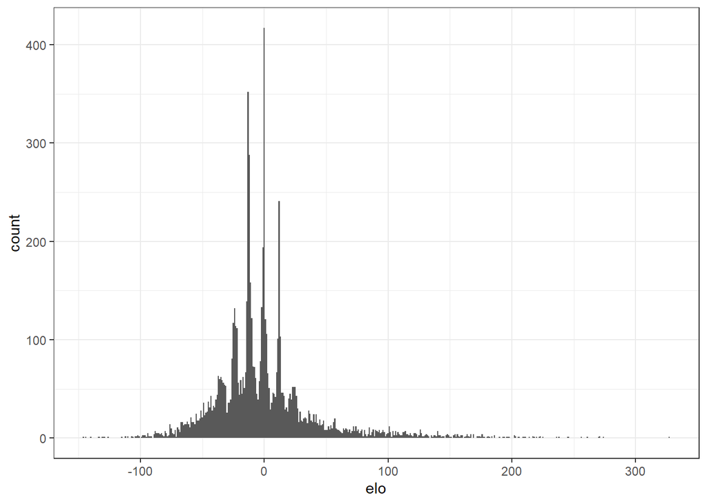

```r
ggplot(data = df9) +
  geom_histogram(mapping = aes(x = elo), binwidth = 1) +
  theme_bw()
```

La distribuzione dei punteggi elo è diversa da quella dei punteggi perché i due approcci al punteggio sfruttano formule molto diverse (una banale somma nei punteggi, una formula basata sulla funzione logistica negli elo). Innanzitutto perché per gli elo abbiamo anche numeri negativi e inoltre sembra molto meno concentrata. ELO infatti permette anche a giocatori che hanno fatto poche partite di non avere punteggi infimi.

Verifichiamo che la somma è zero:

```r
sum(df9$elo)
```

```
## [1] 9.476309e-13
```

A causa delle approssimazioni non è esattamente zero, tuttavia è prossima alla precisione macchina.

## Legame tra punti classici e elo

Costruiamo il dataset che contenga entrambi i punteggi:

```r
df10 <- inner_join(df8, df9, join_by(giocatore))
df10
```

```
## # A tibble: 7,301 × 3
##    giocatore punti    elo
##        <int> <dbl>  <dbl>
##  1         1  31   102.
##  2         2   0.5  -1.81
##  3         3   3   -20.0
##  4         4  23.5 -10.2
##  5         5   4   -43.5
##  6         6   7    12.6
##  7         7  14   -12.7
##  8         8   0   -13.0
##  9         9   0.5 -21.1
## 10        10   3   -86.0
## # ℹ 7,291 more rows
```

Creiamo un grafico per studiare la correlazione tra punti e elo:

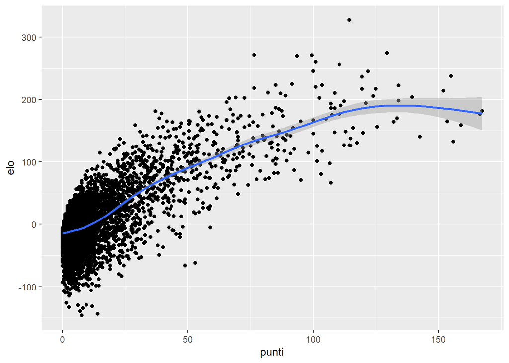

```r
ggplot(data = df10, mapping = aes(x = punti, y = elo)) +
  geom_point() +
  geom_smooth()
```

Dal grafico si vede che a elo più alti corrispondono anche punteggi più alti. Ciò è anche più visibile passando a scale logaritmiche:

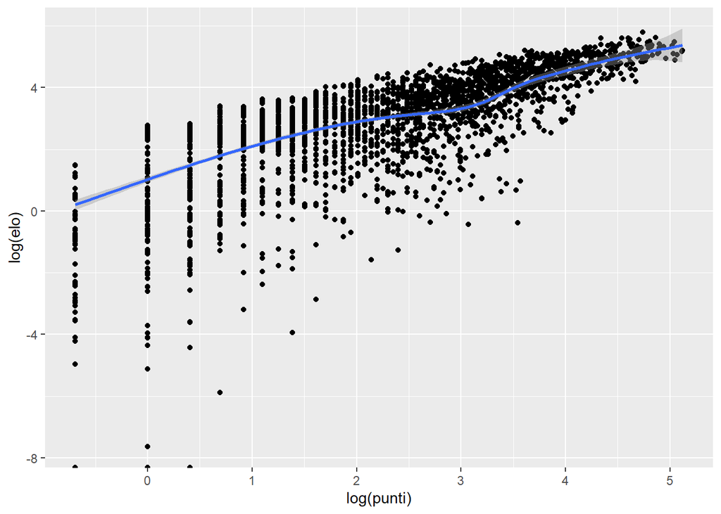

```r
ggplot(data = df10, mapping = aes(x = log(punti), y = log(elo))) +
  geom_point() +
  geom_smooth()
```

I coefficienti di correlazione di Pearson, Spearmann e Kendall valgono:

```r
cor.test(df10$punti, df10$elo, method = "pearson")
```

```
##
##  Pearson's product-moment correlation
##
## data:  df10$punti and df10$elo
## t = 88.609, df = 7299, p-value < 2.2e-16
## alternative hypothesis: true correlation is not equal to 0
## 95 percent confidence interval:
##  0.7086507 0.7307588
## sample estimates:
##       cor
## 0.7198872
```

```r
cor.test(df10$punti, df10$elo, method = "spearman")
```

```
##
##  Spearman's rank correlation rho
##
## data:  df10$punti and df10$elo
## S = 3.8467e+10, p-value < 2.2e-16
## alternative hypothesis: true rho is not equal to 0
## sample estimates:
##      rho
## 0.406949
```

```r
cor.test(df10$punti, df10$elo, method = "kendall")
```

```
##
##  Kendall's rank correlation tau
##
## data:  df10$punti and df10$elo
## z = 37.052, p-value < 2.2e-16
## alternative hypothesis: true tau is not equal to 0
## sample estimates:
##       tau
## 0.2961173
```

Dai quali emerge quindi una correlazione positiva trai due punteggi.

Vediamo se i giocatori più forti nell’uno e nell’altro punteggio sono gli stessi:

```r
df11 <- df10 |>
  arrange(desc(punti)) |>
  head(100);
df12 <- df10 |>
  arrange(desc(elo)) |>
  head(100);
df13 <- df11 |>
  intersect(df12);
righe <- df13 |> nrow();
righe
```

```
## [1] 53
```

Guardando i 100 migliori giocatori in un metodo e i 100 nell’altro scopriamo che solo 53 compaiono in entrambre le top 100: questo significa che non sono eccessivamente discordanti, tuttavia i due metodi portano a classifiche diverse per circa metà (quantomeno nella vetta).

## Dipendenza dal numero di partite giocate

```r
df14 <- df |> select(giocatore = White)
df15 <- df |> select(giocatore = Black)
df16 <- bind_rows(df14, df15)
df17 <- df16 |>
  group_by(giocatore) |>
  summarize(partite = n())
df17
```

```
## # A tibble: 7,301 × 2
##    giocatore partite
##        <int>   <int>
##  1         1      52
##  2         2       1
##  3         3       8
##  4         4      46
##  5         5      13
##  6         6      13
##  7         7      33
##  8         8       1
##  9         9       3
## 10        10      14
## # ℹ 7,291 more rows
```

```r
df18 <- df10 |>
  inner_join(df17)
df18
```

```
## # A tibble: 7,301 × 4
##    giocatore punti    elo partite
##        <int> <dbl>  <dbl>   <int>
##  1         1  31   102.        52
##  2         2   0.5  -1.81       1
##  3         3   3   -20.0        8
##  4         4  23.5 -10.2       46
##  5         5   4   -43.5       13
##  6         6   7    12.6       13
##  7         7  14   -12.7       33
##  8         8   0   -13.0        1
##  9         9   0.5 -21.1        3
## 10        10   3   -86.0       14
## # ℹ 7,291 more rows
```

Possiamo ora creare i grafici per capire se punti e elo dipendono dal numero di partite:

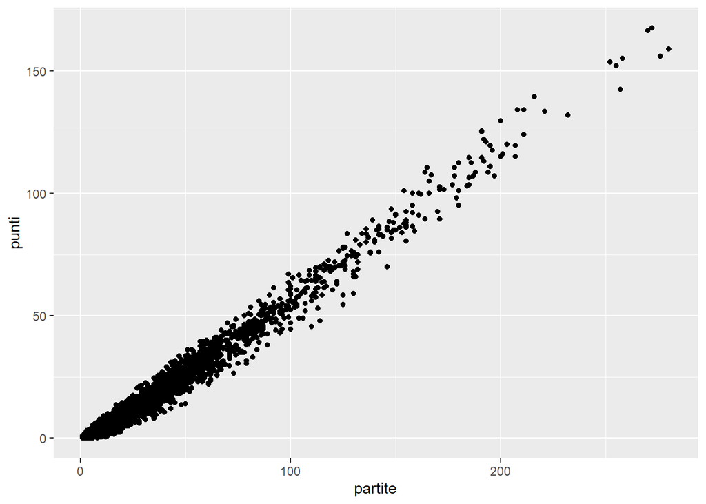

```r
ggplot(data = df18, mapping = aes(x = partite, y = punti)) +
  geom_point()
```

I punti presentano una evidente dipendenza lineare dal numero di partite giocate.

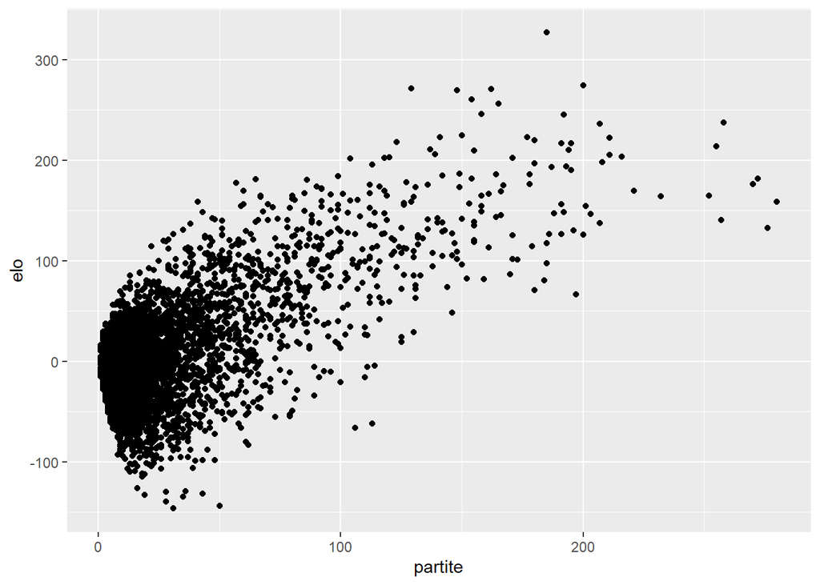

```r
ggplot(data = df18, mapping = aes(x = partite, y = elo)) +
  geom_point()
```

Per gli elo questa dipendenza è molto meno marcata.